# Analysis of Drop-seq data

In this document I will be detailing the analysis of Drop-seq data we received from Sisi Chen of the Thomson lab out of UCSF.

# Preliminary analysis

Each timepoint was demultiplexed using Illumina software, resulting in 4 pairs of fastq files. The first mate is 25 base pairs (bp) and the second mate is 50 bp. The first mate should correspond to the 12 bp cell barcode and a 8 bp unique molecular identifier. To verify the former, we can look at the distribution of cell barcodes for barcodes of length 10-14. We can just look at one of the timepoints.

```r
par(mfrow = c(1,5))
for(i in 10:14){
  x = paste("awk '{if (NR % 4 == 2) print $0}' AAGGAGTA_1.fastq | cut -c 1-", i, " | sort | uniq -c | awk -v OFS='\t' '{print $2, $1}' > AAGGAGTA_", i, "bp_barcode_counts.txt", sep = "")
  system(x)
  counts = read.table(file = paste("AAGGAGTA_", i, "bp_barcode_counts.txt", sep = ""))
  counts_hist = hist(counts[,2], breaks = 0:max(counts[,2]), xlim = c(0, 10))
}
```

### Head of counts histogram for first 10-14 bp of AAGGAGTA_1.fastq

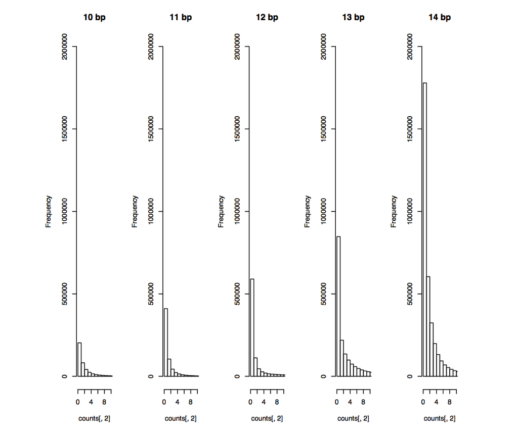

The total number of counts looks as follows:

| total counts | bp |
| --- | --- |
| 448106 | 10 |
| 721391 | 11 |
| 1094593 | 12 |
| 1940900 | 13 |
| 3745861 | 14 |

There seems to be a definite jump from 12 to13 bp, indicating that after 12bp the next base is more random than the previous base. Later, when we take into account UMIs we’ll investigate what minimum threshold is needed for a cell barcoded to be counted.

Let’s take a look at the nucleotide and quality score distribution over all the timepoints using FastQC (http://www.bioinformatics.babraham.ac.uk/projects/fastqc/).

### Cell barcodes nucleotide distribution

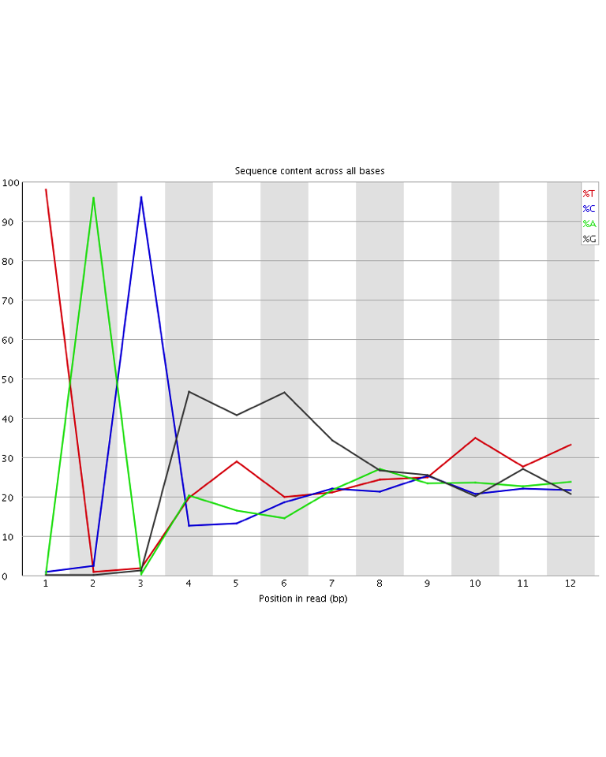

### Cell barcodes quality distribution

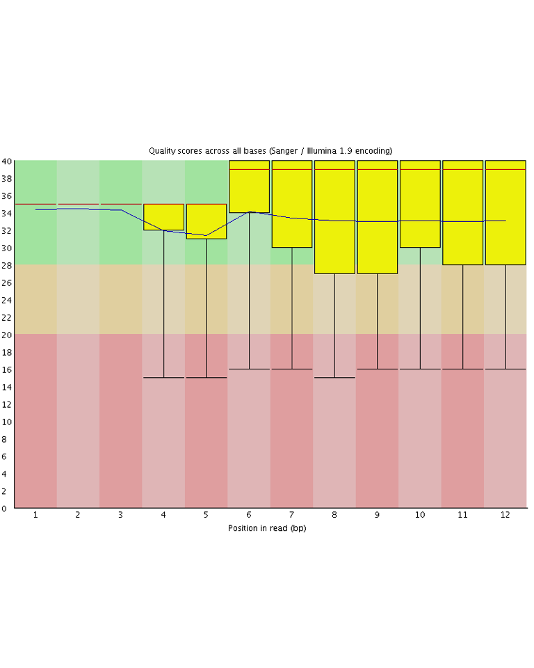

It seems like there are problems with the nucleotide content of the first few bases. There is a vast preponderance of TAC in the first three bases (over $95 \%$ of the reads). This is likely due to biases in the experimental protocol of generating barcodes. It shouldn’t concern us too much, but the quality scores should. The Drop-seq Alignment cookbook v1.1 (http://mccarrolllab.com/wp-content/uploads/2015/05/Drop-seqAlignmentCookbook_v1.1Aug2015.pdf) suggests dropping reads with any quality score below 10, corresponding to a 1 in 10 chance of the nucleotide being incorrect. This may too lenient, we may want to restict ourselves to a higher quality score standard. There are a total of 85,689,564 reads in the intial file. If we restrict ourselves to cell barcodes that have quality scores all above 10 then we get 81,966,026 reads while if we restrict the quality scores to all above 20 then we get 51,876,289 reads. I think we can be liberal here and later remove cells with low barcode counts.

Now let’s look at the UMIs

### UMI nucleotide distribution

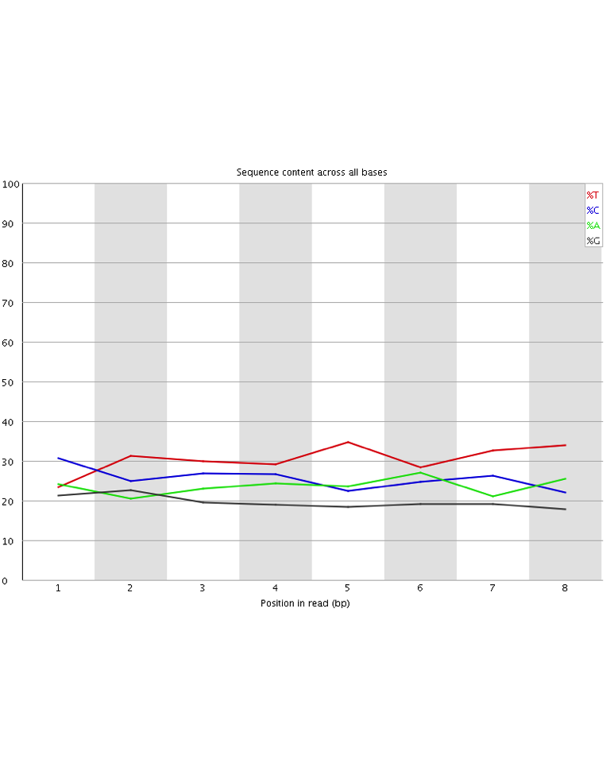

### UMI nucleotide quality distribution

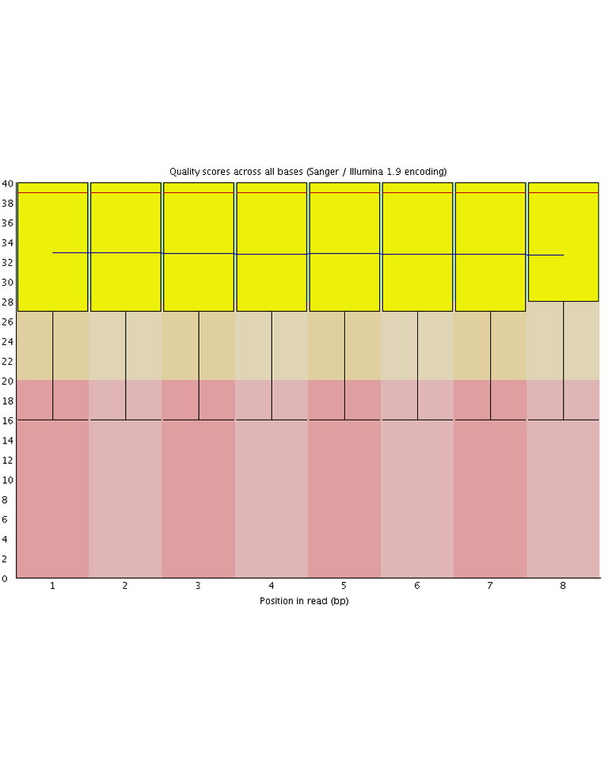

These look perfectly reasonable, though it looks like Ts get more common in later position and Gs get less common.

## Getting Digital Gene Expression (DGE)

We will first follow the recommendations of the Drop-seqAlignmentCookbook v1.1 (http://mccarrolllab.com/wp-content/uploads/2015/05/Drop-seqAlignmentCookbook_v1.1Aug2015.pdf). Since there is an issue with the gtf format needed with software provided, we use the mm10 genome and gene reference available from McCarroll lab and associated with Gene Expression Omnibus accession GSE63472 (http://www.ncbi.nlm.nih.gov/geo/query/acc.cgi?acc=GSE63472). We modify a few things from original pipeline. We collapse cell barcodes and UMIs using an edit distance of 1. We allow for more cells, or cell barcodes, and require a fewer number of distinct UMIs per cell barcode (10) to count a cell.

```bash
mkdir tmp

java -jar -Xmx8g ~/picard-tools-1.141/picard.jar FastqToSam F1=input_R1.fastq F2=input_R2.fastq SORT_ORDER=queryname O=input.sam SM=input TMP_DIR=tmp

rm -r tmp/

~/Drop-seq_tools-1.12/TagBamWithReadSequenceExtended INPUT=input.sam OUTPUT=input_barcoded.sam BASE_RANGE=1-12 BARCODED_READ=1 TAG_NAME=XB SUMMARY=input_cell_barcode_summary.txt BASE_QUALITY=10 NUM_BASES_BELOW_QUALITY=1

rm input.sam

~/Drop-seq_tools-1.12/TagBamWithReadSequenceExtended INPUT=input_barcoded.sam OUTPUT=input_barcoded_UMI.sam BASE_RANGE=13-20 BARCODED_READ=1 BASE_QUALITY=10 DISCARD_READ=TRUE TAG_NAME=XU

rm input_barcoded.sam

~/Drop-seq_tools-1.12/FilterBAM INPUT=input_barcoded_UMI.sam OUTPUT=input_filtered.sam

rm input_barcoded_UMI.sam

~/Drop-seq_tools-1.12/TrimStartingSequence I=input_filtered.sam O=input_filtered_ss_trimmed.sam SEQUENCE=AAGCAGTGGTATCAACGCAGAGTGAATGGG MISMATCHES=0 NUM_BASES=6
rm input_filtered.sam

~/Drop-seq_tools-1.12/PolyATrimmer I=input_filtered_ss_trimmed.sam O=input_trimmed.sam MISMATCHES=0 NUM_BASES=6

rm input_filtered_ss_trimmed.sam

java -Xmx8g -jar ~/picard-tools-1.141/picard.jar SamToFastq INPUT=input_trimmed.sam FASTQ=input_trimmed.fastq

mkdir mapped/

~/aligners/STAR/bin/Linux_x86_64_static/STAR --genomeDir ~/scratch/genomes/mm10/DropSeq/ --readFilesIn input_trimmed.fastq --outFileNamePrefix mapped/ --outSAMtype BAM Unsorted --sjdbGTFfile ~/scratch/genomes/mm10/DropSeq/mm10.gtf

java -jar -Xmx12g ~/picard-tools-1.141/picard.jar MergeBamAlignment UNMAPPED=input_trimmed.sam ALIGNED=mapped/Aligned.out.bam REFERENCE_SEQUENCE=~/scratch/genomes/mm10/DropSeq/mm10.fasta INCLUDE_SECONDARY_ALIGNMENTS=false PAIRED_RUN=false SORT_ORDER=queryname ALIGNED_READS_ONLY=true OUTPUT=input_mapped.bam

rm input_trimmed.sam

rm mapped/Aligned.out.bam

~/Drop-seq_tools-1.12/TagReadWithGeneExon I=input_mapped.bam O=input_mapped_gene_counts.bam TAG=GE ANNOTATIONS_FILE=~/scratch/genomes/mm10/DropSeq/mm10.gtf USE_STRAND_INFO=false ALLOW_MULTI_GENE_READS=false

rm input_mapped.bam

~/samtools-1.3/samtools sort input_mapped_gene_counts.bam -o input_mapped_gene_counts.sort.bam

rm input_mapped_gene_counts.bam

~/Drop-seq_tools-1.12/DetectBeadSynthesisErrors I=input_mapped_gene_counts.sort.bam O=input_mapped_clean_gene_counts.sort.bam SUMMARY=input_bead_clean_summary.txt CELL_BARCODE_TAG=XB MOLECULAR_BARCODE_TAG=XU GENE_EXON_TAG=GE MIN_UMIS_PER_CELL=10 NUM_BARCODES=10000 OUTPUT_STATS=input_bead_clean_out.txt

~/Drop-seq_tools-1.12/DigitalExpression SUMMARY=input_DGE_summary.txt O=input_DGE_matrix.txt I=input_mapped_clean_gene_counts.sort.bam CELL_BARCODE_TAG=XB MOLECULAR_BARCODE_TAG=XU GENE_EXON_TAG=GE EDIT_DISTANCE=1 NUM_CORE_BARCODES=10000
```

# Analysing the DGE

Now that we have digital gene expression profiles we can start analysing it.

```r
day0_DGE_matrix = read.table(file = "AAGGAGTA_DGE_matrix.txt", header = TRUE, row.names = 1)
day2_DGE_matrix = read.table(file = "ACTGCATA_DGE_matrix.txt", header = TRUE, row.names = 1)
day5_DGE_matrix = read.table(file = "CTAAGCCT_DGE_matrix.txt", header = TRUE, row.names = 1)
day8_DGE_matrix = read.table(file = "GTAAGGAG_DGE_matrix.txt", header = TRUE, row.names = 1)
# original sizes of the matrices
dim(day0_DGE_matrix)
```

```
## [1] 16169 10000
```

```r
dim(day2_DGE_matrix)
```

```
## [1] 14562 10000
```

```r
dim(day5_DGE_matrix)
```

```
## [1] 16463 10000
```

```r
dim(day8_DGE_matrix)
```

```
## [1] 13929 10000
```

# Aggregate gene expression analysis

For a rough idea of the differences between time points we can combine the single cells into a single experiment and look at differential expression.

```r
# treat combined single cells as a low-input RNA-seq experiment
day0_combined_DGE = rowSums(day0_DGE_matrix)
day2_combined_DGE = rowSums(day2_DGE_matrix)
day5_combined_DGE = rowSums(day5_DGE_matrix)
day8_combined_DGE = rowSums(day8_DGE_matrix)
# workaround to get all genes
all_days_combined_DGE = mat.or.vec(nr = length(union(names(day0_combined_DGE), union(names(day2_combined_DGE), union(names(day5_combined_DGE), names(day8_combined_DGE))))), nc = 4)
rownames(all_days_combined_DGE) = union(names(day0_combined_DGE), union(names(day2_combined_DGE), union(names(day5_combined_DGE), names(day8_combined_DGE))))
colnames(all_days_combined_DGE) = c("day0", "day2", "day5", "day8")

for(i in rownames(all_days_combined_DGE)){
  if(i %in% names(day0_combined_DGE)){
    all_days_combined_DGE[i, "day0"] = day0_combined_DGE[i]
  }}
for(i in rownames(all_days_combined_DGE)){
  if(i %in% names(day2_combined_DGE)){
    all_days_combined_DGE[i, "day2"] = day2_combined_DGE[i]
  }}
for(i in rownames(all_days_combined_DGE)){
  if(i %in% names(day5_combined_DGE)){
    all_days_combined_DGE[i, "day5"] = day5_combined_DGE[i]
  }}
for(i in rownames(all_days_combined_DGE)){
  if(i %in% names(day8_combined_DGE)){
    all_days_combined_DGE[i, "day8"] = day8_combined_DGE[i]
  }}

#filter missing genes
all_days_combined_DGE = all_days_combined_DGE[which(rowSums(all_days_combined_DGE) > 1), ]

# use DESeq2 to look for differentially expressed genes
source("https://bioconductor.org/biocLite.R")
```

```
## Bioconductor version 3.2 (BiocInstaller 1.20.1), ?biocLite for help
```

```r
biocLite("DESeq2")
```

```
## BioC_mirror: https://bioconductor.org
```

```
## Using Bioconductor 3.2 (BiocInstaller 1.20.1), R 3.2.3 (2015-12-10).
```

```
## Installing package(s) 'DESeq2'
```

```
##
##  /var/folders/8m/0f0r_lmn4p5bmrzymmp2d0qr0000gn/T//Rtmp2GiTK1/downloaded_packages
```

```r
library(DESeq2)
all_days_combined_coldata = data.frame("days" = c(0, 2, 5, 8))
rownames(all_days_combined_coldata) = c("day0", "day2", "day5", "day8")
all_days_combined_deseqdataseq = DESeqDataSetFromMatrix(countData=all_days_combined_DGE, colData= all_days_combined_coldata, design = ~ days)
```

```
## the design formula contains a numeric variable with integer values,
##   specifying a model with increasing fold change for higher values.
##   did you mean for this to be a factor? if so, first convert
##   this variable to a factor using the factor() function
```

```r
# LRT, null model is empty, intercept only
all_days_combined_deseq = DESeq(all_days_combined_deseqdataseq, test="Wald")
all_days_combined_deseq_results = results(all_days_combined_deseq)
head(all_days_combined_deseq_results[order(all_days_combined_deseq_results$padj),])
```

```
## log2 fold change (MAP): days
## Wald test p-value: days
## DataFrame with 6 rows and 6 columns
##         baseMean log2FoldChange      lfcSE      stat       pvalue
##        <numeric>      <numeric>  <numeric> <numeric>    <numeric>
## Gal    202.85120     -0.7021755 0.07300264 -9.618494 6.680173e-22
## Igf2   131.15946     -0.4351218 0.06915305 -6.292157 3.130852e-10
## Pim2   266.00297     -0.3850703 0.07041912 -5.468263 4.544683e-08
## Krt18  104.03904     -0.3342630 0.06753073 -4.949791 7.429305e-07
## Spock3  42.58373     -0.3550027 0.07393566 -4.801509 1.574746e-06
## Anxa2  114.88328     -0.3142050 0.06625500 -4.742359 2.112435e-06
##                padj
##           <numeric>
## Gal    6.090982e-18
## Igf2   1.427355e-06
## Pim2   1.381281e-04
## Krt18  1.693510e-03
## Spock3 2.871707e-03
## Anxa2  3.114778e-03
```

```r
all_days_combined_DGE[rownames(head(all_days_combined_deseq_results[order(all_days_combined_deseq_results$padj),])), ]
```

```
##        day0 day2 day5 day8
## Gal     873   21    2    1
## Igf2    333  130   70    3
## Pim2    587  296  196    4
## Krt18   251   90   85   10
## Spock3  123   34   21    0
## Anxa2   300   78   96   17
```

```r
head(all_days_combined_deseq_results[order(all_days_combined_deseq_results$log2FoldChange, decreasing = TRUE),])
```

```
## log2 fold change (MAP): days
## Wald test p-value: days
## DataFrame with 6 rows and 6 columns
##          baseMean log2FoldChange      lfcSE      stat       pvalue
##         <numeric>      <numeric>  <numeric> <numeric>    <numeric>
## Slc30a2  56.57310      0.3500882 0.07421542  4.717189 2.391253e-06
## Alpl     40.27491      0.3328737 0.07368607  4.517458 6.258653e-06
## Bmp4     61.98812      0.3271287 0.07425241  4.405631 1.054764e-05
## Tdgf1   125.78898      0.3146779 0.07294252  4.314053 1.602883e-05
## Klf4     56.82127      0.2966272 0.07411742  4.002125 6.277608e-05
## Calb2    27.74602      0.2844403 0.07299480  3.896719 9.750448e-05
##                padj
##           <numeric>
## Slc30a2 0.003114778
## Alpl    0.006779940
## Bmp4    0.009617343
## Tdgf1   0.013286444
## Klf4    0.035774516
## Calb2   0.047351627
```

```r
all_days_combined_DGE[rownames(head(all_days_combined_deseq_results[order(all_days_combined_deseq_results$log2FoldChange, decreasing = TRUE), ])), ]
```

```
##         day0 day2 day5 day8
## Slc30a2    6    6    6  185
## Alpl       7    5   31  112
## Bmp4       2   18   11  190
## Tdgf1     20   42   31  361
## Klf4       6   14    5  177
## Calb2      2    5    3   89
```

```r
all_days_combined_top_genes = head(order(all_days_combined_deseq_results$padj), length(which(all_days_combined_deseq_results$padj < 0.05)))
all_days_combined_DGE[all_days_combined_top_genes, ]
```

```
##               day0 day2 day5 day8
## Gal            873   21    2    1
## Igf2           333  130   70    3
## Pim2           587  296  196    4
## Krt18          251   90   85   10
## Spock3         123   34   21    0
## Anxa2          300   78   96   17
## Slc30a2          6    6    6  185
## 3110079O15Rik  103   86    6    0
## Alpl             7    5   31  112
## Bmp4             2   18   11  190
## Tdgf1           20   42   31  361
## Ctsw            80   23    9    0
## Areg            70   16    1    0
## Pou3f1         201  167   94    2
## Lgals1         347   64  126   24
## Klf4             6   14    5  177
## Calb2            2    5    3   89
## Id1            241   49  102    4
## Nes            243   78  121   14
```

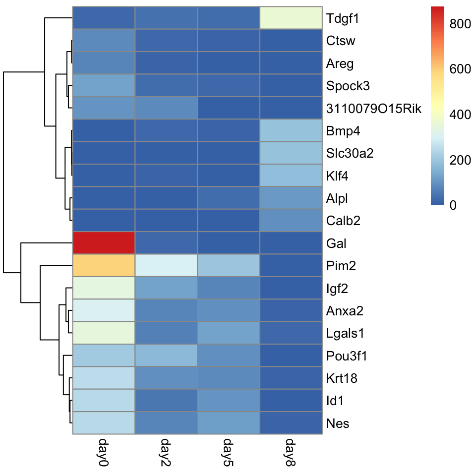

```r
# heatmap of top expressed genes
install.packages('pheatmap', repos = "http://cran.r-project.org")
library(pheatmap)
pheatmap(all_days_combined_DGE[all_days_combined_top_genes, ], cluster_col = FALSE)
```

There appears to be two major modules here, one in days 0, 2, and 5 consisting of Pim2, Igf2, Anxa2, Lgals1, Pou3f1, Krt18, Id1, and Nes and one in day 8 consisting of Bmp4, Slc30a2, Klf4, Alpl, and Calb2. Additionally it appears to be two very specific genes, Gal for day 0 and Tdgf1 for day 8.

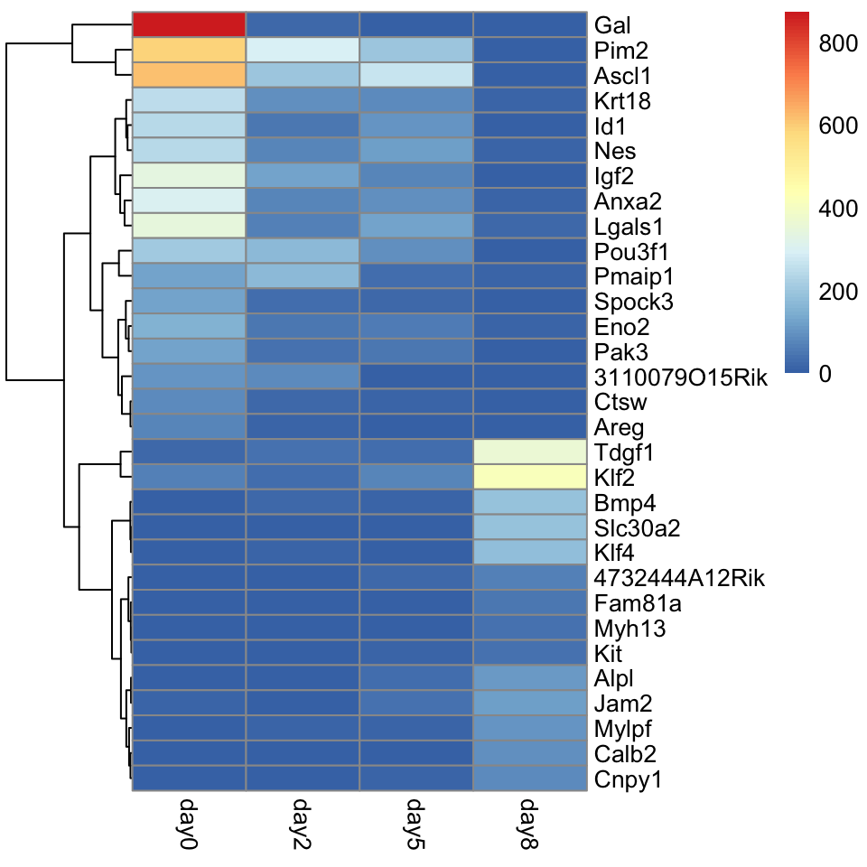

```r
# increase FDR to 0.1
all_days_combined_top_genes = head(order(all_days_combined_deseq_results$padj), length(which(all_days_combined_deseq_results$padj < 0.1)))
# heatmap of top expressed genes
pheatmap(all_days_combined_DGE[all_days_combined_top_genes, ], cluster_col = FALSE)
```

# Single cell analysis

## How many cells to consider?

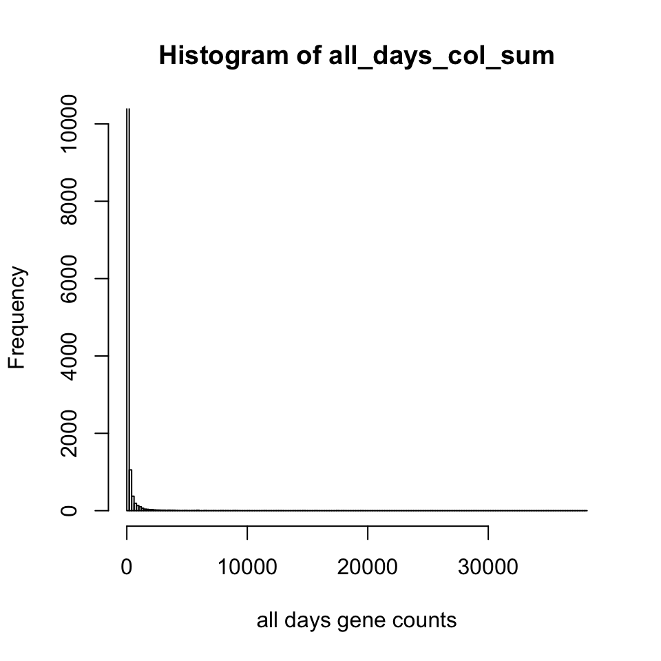

```r
# large number of low count cells
all_days_col_sum = c(colSums(day0_DGE_matrix), colSums(day2_DGE_matrix), colSums(day5_DGE_matrix), colSums(day8_DGE_matrix))
hist(all_days_col_sum, breaks = 200, ylim = c(0, 10000), xlab = "all days gene counts")
```

```r
# how many counts to require to identify a cell?
# fit a negative binomial, set min count to be 90th percentile
library(MASS)
all_days_col_sum.nb_fit = fitdistr(all_days_col_sum, densfun = "negative binomial")
all_days_col_sum.thresh = qnbinom(0.99, size = all_days_col_sum.nb_fit$estimate[1], mu = all_days_col_sum.nb_fit$estimate[2])
day0_DGE_matrix = day0_DGE_matrix[ , colSums(day0_DGE_matrix) > all_days_col_sum.thresh]
day2_DGE_matrix = day2_DGE_matrix[ , colSums(day2_DGE_matrix) > all_days_col_sum.thresh]
day5_DGE_matrix = day5_DGE_matrix[ , colSums(day5_DGE_matrix) > all_days_col_sum.thresh]
day8_DGE_matrix = day8_DGE_matrix[ , colSums(day8_DGE_matrix) > all_days_col_sum.thresh]
dim(day0_DGE_matrix)
```

```
## [1] 16169   215
```

```r
dim(day2_DGE_matrix)
```

```
## [1] 14562   167
```

```r
dim(day5_DGE_matrix)
```

```
## [1] 16463   282
```

```r
dim(day8_DGE_matrix)
```

```
## [1] 13929   158
```

```r
# we should really fit a two component distribution and select only those in the larger distro

# let's consider the top 100 cells for each condition to make like easier
day0_top100cells_DGE_matrix = day0_DGE_matrix[ ,sort(colSums(day0_DGE_matrix), index = T, decreasing = TRUE)$ix[1:100]]
day2_top100cells_DGE_matrix = day2_DGE_matrix[ ,sort(colSums(day2_DGE_matrix), index = T, decreasing = TRUE)$ix[1:100]]
day5_top100cells_DGE_matrix = day5_DGE_matrix[ ,sort(colSums(day5_DGE_matrix), index = T, decreasing = TRUE)$ix[1:100]]
day8_top100cells_DGE_matrix = day8_DGE_matrix[ ,sort(colSums(day8_DGE_matrix), index = T, decreasing = TRUE)$ix[1:100]]

# now we need to combine the days into a full dataset
length(intersect(intersect(intersect(rownames(day0_top100cells_DGE_matrix), rownames(day2_top100cells_DGE_matrix)), rownames(day5_top100cells_DGE_matrix)), rownames(day8_top100cells_DGE_matrix)))
```

```
## [1] 11574
```

```r
length(union(union(union(rownames(day0_top100cells_DGE_matrix), rownames(day2_top100cells_DGE_matrix)), rownames(day5_top100cells_DGE_matrix)), rownames(day8_top100cells_DGE_matrix)))
```

```
## [1] 19559
```

```r
# filter out genes that don't have many reads
day0_top100cells_DGE_matrix = day0_top100cells_DGE_matrix[rowSums(day0_top100cells_DGE_matrix) > 5, ]
day2_top100cells_DGE_matrix = day2_top100cells_DGE_matrix[rowSums(day2_top100cells_DGE_matrix) > 5, ]
day5_top100cells_DGE_matrix = day5_top100cells_DGE_matrix[rowSums(day5_top100cells_DGE_matrix) > 5, ]
day8_top100cells_DGE_matrix = day8_top100cells_DGE_matrix[rowSums(day8_top100cells_DGE_matrix) > 5, ]

all_days_DGE = mat.or.vec(nr = length(union(union(union(rownames(day0_top100cells_DGE_matrix), rownames(day2_top100cells_DGE_matrix)), rownames(day5_top100cells_DGE_matrix)), rownames(day8_top100cells_DGE_matrix))), nc = 400)
rownames(all_days_DGE) = union(rownames(day0_top100cells_DGE_matrix), union(rownames(day2_top100cells_DGE_matrix), union(rownames(day5_top100cells_DGE_matrix), rownames(day8_top100cells_DGE_matrix))))
colnames(all_days_DGE) = c(paste0("day0", colnames(day0_top100cells_DGE_matrix)), paste0("day2", colnames(day2_top100cells_DGE_matrix)), paste0("day5", colnames(day5_top100cells_DGE_matrix)), paste0("day8", colnames(day8_top100cells_DGE_matrix)))

for(i in rownames(all_days_DGE)){
  for(j in 1:100){
    if(i %in% rownames(day0_top100cells_DGE_matrix)){
      all_days_DGE[i, j] = day0_top100cells_DGE_matrix[i,j]
    }
  }
}
for(i in rownames(all_days_DGE)){
  for(j in 1:100){
    if(i %in% rownames(day2_top100cells_DGE_matrix)){
      all_days_DGE[i, j + 100] = day2_top100cells_DGE_matrix[i,j]
    }
  }
}
for(i in rownames(all_days_DGE)){
  for(j in 1:100){
    if(i %in% rownames(day5_top100cells_DGE_matrix)){
      all_days_DGE[i, j + 200] = day5_top100cells_DGE_matrix[i,j]
    }
  }
}
for(i in rownames(all_days_DGE)){
  for(j in 1:100){
    if(i %in% rownames(day8_top100cells_DGE_matrix)){
      all_days_DGE[i, j + 300] = day8_top100cells_DGE_matrix[i,j]
    }
  }
}
```

## Clustering cells

### Principal compenent analysis (PCA)

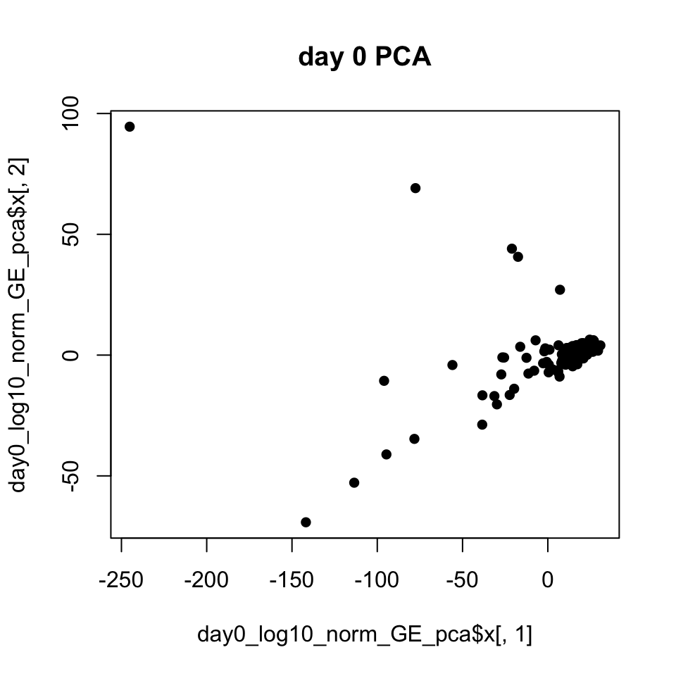

```r
# PCA
# log10 scale first
# Note that we need to use R/3.0.2, get error "Error in La.svd(x, nu, nv) : error code 1 from Lapack routine 'dgesdd'" with version 3.2.2
day0_log10_norm_GE = log10(as.matrix(day0_top100cells_DGE_matrix[rowSums(day0_top100cells_DGE_matrix > 0) > 5, ]) + 1)
day0_log10_norm_GE_pca = prcomp(t(day0_log10_norm_GE), corr = TRUE, scale = TRUE)
plot(day0_log10_norm_GE_pca$x[,1], day0_log10_norm_GE_pca$x[,2], pch = 16, main = "day 0 PCA")
```

There doesn’t appear to be any groupings here. Let’s look at the effect of sampling depth (number of UMIs per cell) has on the PCA.

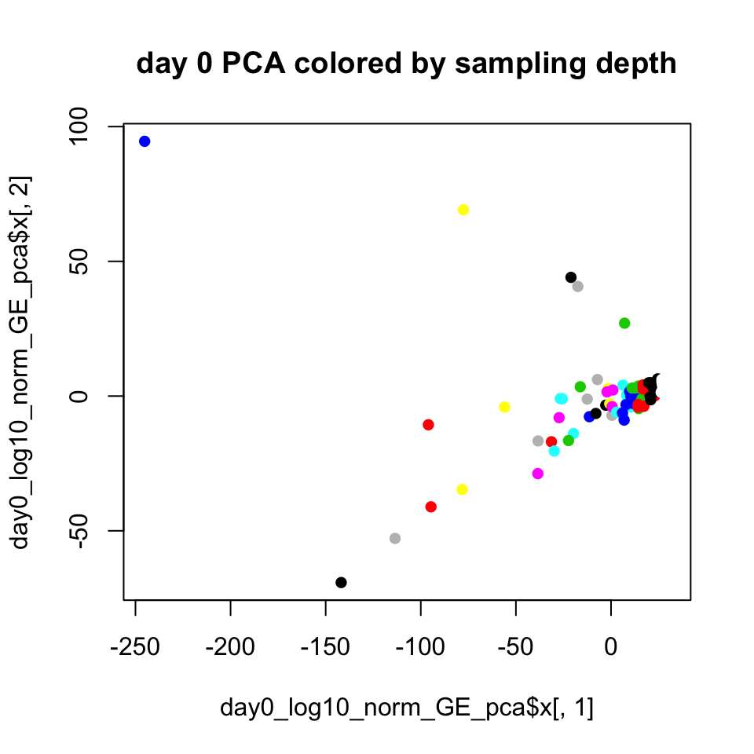

```r
day0_DGE_lib_size = colSums(day0_top100cells_DGE_matrix)
day0_DGE_lib_size = day0_DGE_lib_size - min(day0_DGE_lib_size) + 1
day0_DGE_lib_size = day0_DGE_lib_size/max(day0_DGE_lib_size)
day0_DGE_lib_size = round(day0_DGE_lib_size*100)
plot(day0_log10_norm_GE_pca$x[,1], day0_log10_norm_GE_pca$x[,2], pch = 16, main = "day 0 PCA colored by sampling depth", col = day0_DGE_lib_size)
```

It looks like the first principal component is directly accounting for the sampling depth. In fact, in all time points the correlation between the two is nearly perfectly -1.

```r
day2_log10_norm_GE = log10(as.matrix(day2_top100cells_DGE_matrix[rowSums(day2_top100cells_DGE_matrix > 0) > 5, ]) + 1)
day2_log10_norm_GE_pca = prcomp(t(day2_log10_norm_GE), corr = TRUE, scale = TRUE)
day5_log10_norm_GE = log10(as.matrix(day5_top100cells_DGE_matrix[rowSums(day5_top100cells_DGE_matrix > 0) > 5, ]) + 1)
day5_log10_norm_GE_pca = prcomp(t(day5_log10_norm_GE), corr = TRUE, scale = TRUE)
day8_log10_norm_GE = log10(as.matrix(day8_top100cells_DGE_matrix[rowSums(day8_top100cells_DGE_matrix > 0) > 5, ]) + 1)
day8_log10_norm_GE_pca = prcomp(t(day8_log10_norm_GE), corr = TRUE, scale = TRUE)

c(cor(day0_log10_norm_GE_pca$x[,1], colSums(day0_top100cells_DGE_matrix)), cor(day2_log10_norm_GE_pca$x[,1], colSums(day2_top100cells_DGE_matrix)), cor(day5_log10_norm_GE_pca$x[,1], colSums(day5_top100cells_DGE_matrix)), cor(day8_log10_norm_GE_pca$x[,1], colSums(day8_top100cells_DGE_matrix)) )
```

```
## [1] -0.9814431 -0.9955924 -0.9955117 -0.9835196
```

Since the first factor is effectively the sampling depth we can look at the second and third components.

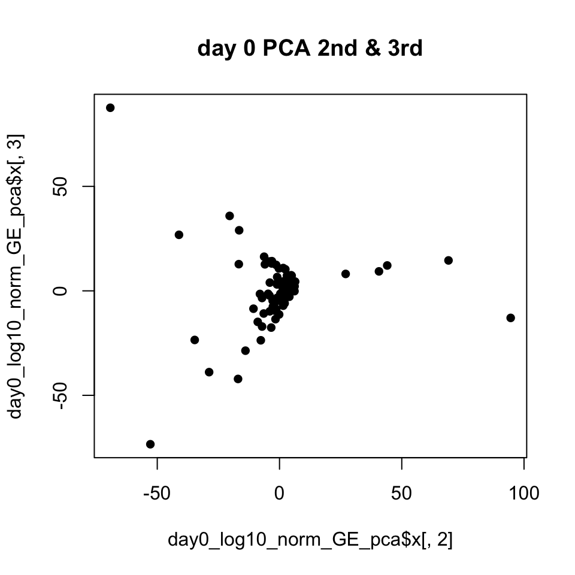

```r
plot(day0_log10_norm_GE_pca$x[,2], day0_log10_norm_GE_pca$x[,3], pch = 16, main = "day 0 PCA 2nd & 3rd")
```

There doesn’t appear to be definitive clusters of cells, except for the possibility that there is one major cluster with outliers. It may be that we need to properly normalize the gene expression counts to account for sampling depth.

## Single-cell differential expression

We’ll use the package scde from [Kharchenko et al.](http://www.nature.com/nmeth/journal/v11/n7/abs/nmeth.2967.html) to look at differential expression in the cells.

```r
install.packages('devtools', repos = "http://cran.r-project.org")
require(devtools)
install_github('hms-dbmi/scde', build_vignettes = FALSE)
require(scde)
```

```r
dim(all_days_DGE)
```

```
## [1] 9827  400
```

```r
all_days_DGE = apply(all_days_DGE, 2, function(x) {storage.mode(x) <- 'integer'; x})
all_days_DGE_scde = scde.error.models(all_days_DGE, groups = c(rep(0, times = 100), rep(2, times = 100), rep(5, times = 100), rep(8, times = 100)), save.model.plots = FALSE)
# look at number of "valid" cells
length(all_days_DGE_scde$corr.a > 0)
```

```
## [1] 400
```

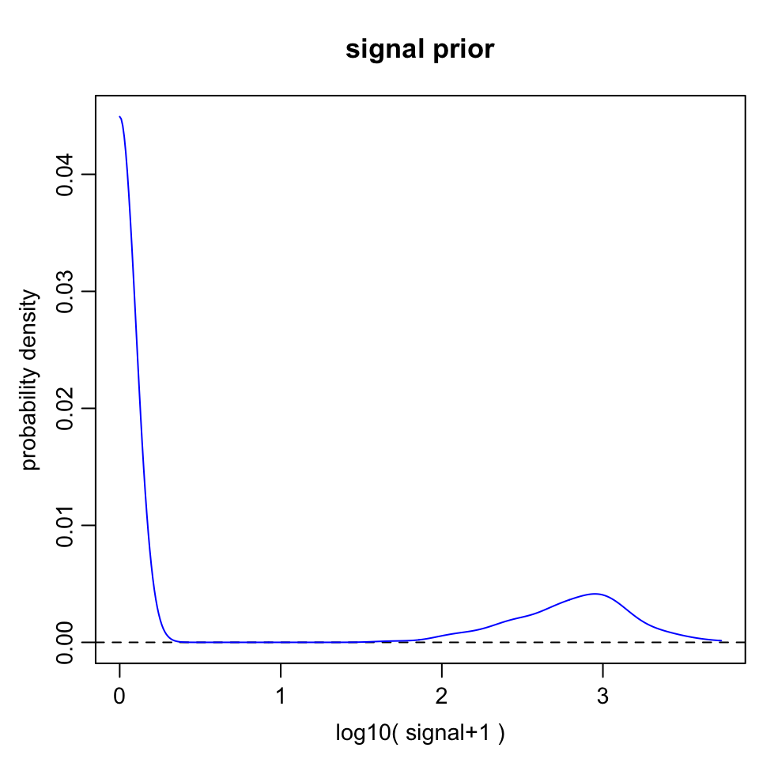

```r
# all cells are valid.  Hooray!
all_days_DGE_scde_prior = scde.expression.prior(models = all_days_DGE_scde, counts = all_days_DGE, show.plot = TRUE)
```

### Day 0 vs Day 8 differential expression

```r
groups = factor(gsub("(day0|day8).*", "\\1", rownames(all_days_DGE_scde)), levels  =  c("day0", "day8"))
day0_vs_day8_scde_diff = scde.expression.difference(all_days_DGE_scde, all_days_DGE, all_days_DGE_scde_prior, groups = groups)
write.table(day0_vs_day8_scde_diff[order(abs(day0_vs_day8_scde_diff$Z), decreasing = TRUE), ], file = "day0_vs_day8_scde_diff.txt", sep = "\t", quote = FALSE, row.names = TRUE, col.names = TRUE)
```

### Day 0 vs Day 2 differential expression

```r
groups = factor(gsub("(day0|day2).*", "\\1", rownames(all_days_DGE_scde)), levels  =  c("day0", "day2"))
day0_vs_day2_scde_diff = scde.expression.difference(all_days_DGE_scde, all_days_DGE, all_days_DGE_scde_prior, groups = groups)
write.table(day0_vs_day2_scde_diff[order(abs(day0_vs_day2_scde_diff$Z), decreasing = TRUE), ], file = "day0_vs_day2_scde_diff.txt", sep = "\t", quote = FALSE, row.names = TRUE, col.names = TRUE)
```

### Day 0 vs Day 5 differential expression

```r
groups = factor(gsub("(day0|day5).*", "\\1", rownames(all_days_DGE_scde)), levels  =  c("day0", "day5"))
day0_vs_day5_scde_diff = scde.expression.difference(all_days_DGE_scde, all_days_DGE, all_days_DGE_scde_prior, groups = groups)
write.table(day0_vs_day5_scde_diff[order(abs(day0_vs_day5_scde_diff$Z), decreasing = TRUE), ], file = "day0_vs_day5_scde_diff.txt", sep = "\t", quote = FALSE, row.names = TRUE, col.names = TRUE)
```

### Day 2 vs Day 5 differential expression

```r
groups = factor(gsub("(day2|day5).*", "\\1", rownames(all_days_DGE_scde)), levels  =  c("day2", "day5"))
day2_vs_day5_scde_diff = scde.expression.difference(all_days_DGE_scde, all_days_DGE, all_days_DGE_scde_prior, groups = groups)
write.table(day2_vs_day5_scde_diff[order(abs(day2_vs_day5_scde_diff$Z), decreasing = TRUE), ], file = "day2_vs_day5_scde_diff.txt", sep = "\t", quote = FALSE, row.names = TRUE, col.names = TRUE)
```

### Day 2 vs Day 8 differential expression

```r
groups = factor(gsub("(day2|day8).*", "\\1", rownames(all_days_DGE_scde)), levels  =  c("day2", "day8"))
day2_vs_day8_scde_diff = scde.expression.difference(all_days_DGE_scde, all_days_DGE, all_days_DGE_scde_prior, groups = groups)
write.table(day2_vs_day8_scde_diff[order(abs(day2_vs_day8_scde_diff$Z), decreasing = TRUE), ], file = "day2_vs_day8_scde_diff.txt", sep = "\t", quote = FALSE, row.names = TRUE, col.names = TRUE)
```

### Day 5 vs Day 8 differential expression

```r
groups = factor(gsub("(day5|day8).*", "\\1", rownames(all_days_DGE_scde)), levels  =  c("day5", "day8"))
day5_vs_day8_scde_diff = scde.expression.difference(all_days_DGE_scde, all_days_DGE, all_days_DGE_scde_prior, groups = groups)
write.table(day5_vs_day8_scde_diff[order(abs(day5_vs_day8_scde_diff$Z), decreasing = TRUE), ], file = "day5_vs_day8_scde_diff.txt", sep = "\t", quote = FALSE, row.names = TRUE, col.names = TRUE)
```

### Loading ENSEMBL reference from BioMart

```r
biocLite("biomaRt")
```

```
## BioC_mirror: https://bioconductor.org
```

```
## Using Bioconductor 3.2 (BiocInstaller 1.20.1), R 3.2.3 (2015-12-10).
```

```
## Installing package(s) 'biomaRt'
```

```
##
##  /var/folders/8m/0f0r_lmn4p5bmrzymmp2d0qr0000gn/T//RtmpyhJeWP/downloaded_packages
```

```r
library(biomaRt)
biocLite("GO.db")
```

```
## BioC_mirror: https://bioconductor.org
```

```
## Using Bioconductor 3.2 (BiocInstaller 1.20.1), R 3.2.3 (2015-12-10).
```

```
## Installing package(s) 'GO.db'
```

```
## installing the source package 'GO.db'
```

```
##
##  '/private/var/folders/8m/0f0r_lmn4p5bmrzymmp2d0qr0000gn/T/RtmpyhJeWP/downloaded_packages'
```

```r
library(GO.db)
ensembl = useMart("ensembl", dataset="mmusculus_gene_ensembl")
go = getBM(attributes = c("external_gene_name", "go_id"), filters = "external_gene_name", values = rownames(all_days_DGE), mart = ensembl)
go$term = Term(go$go_id)
s = split(go$external_gene_name, paste(go$go_id,go$term))
go.env = list2env(s)
```

```r
all_days_DGE_varinfo = pagoda.varnorm(all_days_DGE_scde, counts = all_days_DGE, max.adj.var = 12)
```

[figure not shown]

```r
all_days_DGE_varinfo_minus_libsize = pagoda.subtract.aspect(all_days_DGE_varinfo, colSums(all_days_DGE[, rownames(all_days_DGE_scde)]>0))
```

```r
all_days_DGE_scde_pwpca = pagoda.pathway.wPCA(all_days_DGE_varinfo_minus_libsize, go.env, n.components = 1, n.cores = 1)
```

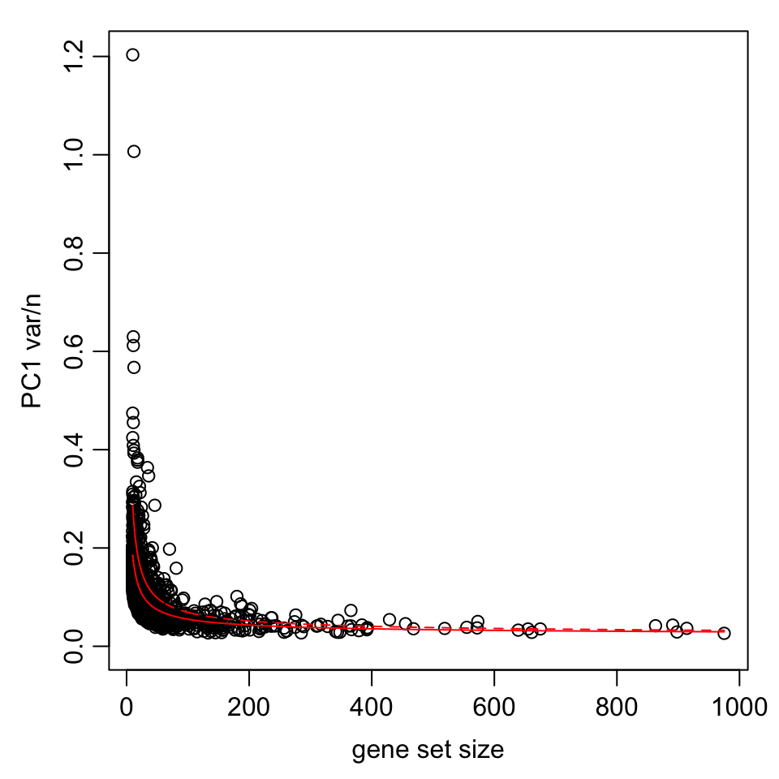

```r
all_days_DGE_scde_pwpca_df = pagoda.top.aspects(all_days_DGE_scde_pwpca, return.table = TRUE, plot = TRUE, z.score = 1.96)
```

```r
head(all_days_DGE_scde_pwpca_df)
```

```
##                                                     name npc  n    score
## 996                   GO:0019933 cAMP-mediated signaling   1 10 6.509416
## 621            GO:0007218 neuropeptide signaling pathway   1 12 6.120292
## 1509                     GO:0043627 response to estrogen   1 34 4.028756
## 1258                      GO:0032868 response to insulin   1 36 3.955934
## 1048                        GO:0030141 secretory granule   1 46 3.698690
## 2027 GO:2000273 positive regulation of receptor activity   1 11 3.622108
##             z    adj.z sh.z adj.sh.z
## 996  25.92333 25.62812   NA       NA
## 621  25.60782 25.33627   NA       NA
## 1509 22.25708 21.96269   NA       NA
## 1258 22.17867 21.89635   NA       NA
## 1048 22.09290 21.81968   NA       NA
## 2027 14.87290 14.51260   NA       NA
```

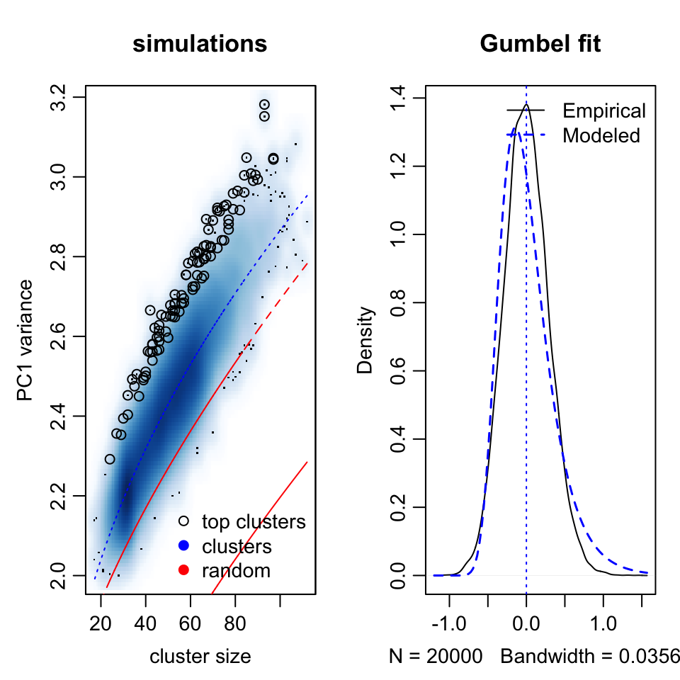

```r
all_days_DGE_scde_gene_clusters = pagoda.gene.clusters(all_days_DGE_varinfo_minus_libsize, n.clusters = 200, n.samples = 100, plot = TRUE, n.cores = 1)
```

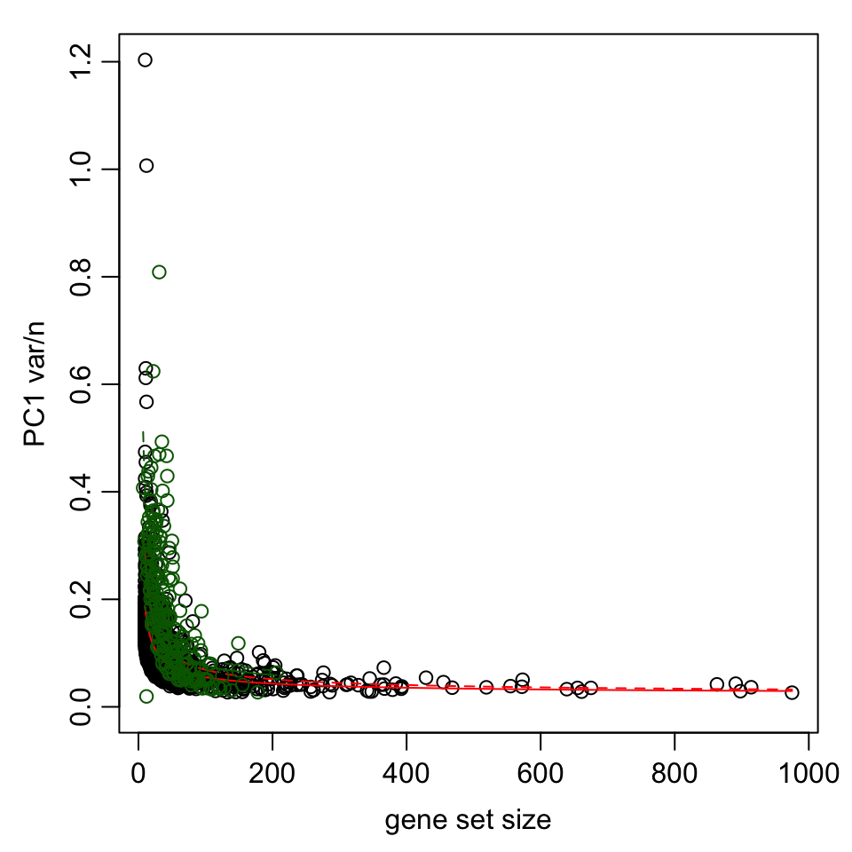

```r
all_days_DGE_scde_top_gene_clusters = pagoda.top.aspects(all_days_DGE_scde_pwpca, all_days_DGE_scde_gene_clusters, return.table = TRUE, plot = TRUE, z.score = 1.96)
```

```r
head(all_days_DGE_scde_top_gene_clusters)
```

```
##                                           name npc  n    score        z
## 996         GO:0019933 cAMP-mediated signaling   1 10 6.509416 25.92333
## 621  GO:0007218 neuropeptide signaling pathway   1 12 6.120292 25.60782
## 2125                            geneCluster.85   1 31 6.067069 16.63123
## 2177                           geneCluster.137   1 42 4.102012 13.77698
## 1509           GO:0043627 response to estrogen   1 34 4.028756 22.25708
## 1258            GO:0032868 response to insulin   1 36 3.955934 22.17867
##         adj.z sh.z adj.sh.z
## 996  25.62812   NA       NA
## 621  25.33627   NA       NA
## 2125 16.31072   NA       NA
## 2177 13.44038   NA       NA
## 1509 21.96269   NA       NA
## 1258 21.89635   NA       NA
```

```r
all_days_DGE_scde_all_gene_clusters = pagoda.top.aspects(all_days_DGE_scde_pwpca, all_days_DGE_scde_gene_clusters, n.cells = NULL, z.score = qnorm(0.01/2, lower.tail = FALSE))
```

```r
all_days_DGE_scde_cluster_cells = pagoda.cluster.cells(all_days_DGE_scde_all_gene_clusters, all_days_DGE_varinfo_minus_libsize)
```

```r
all_days_DGE_scde_reduced_gene_clusters = pagoda.reduce.loading.redundancy(all_days_DGE_scde_all_gene_clusters, all_days_DGE_scde_pwpca, all_days_DGE_scde_gene_clusters)
```

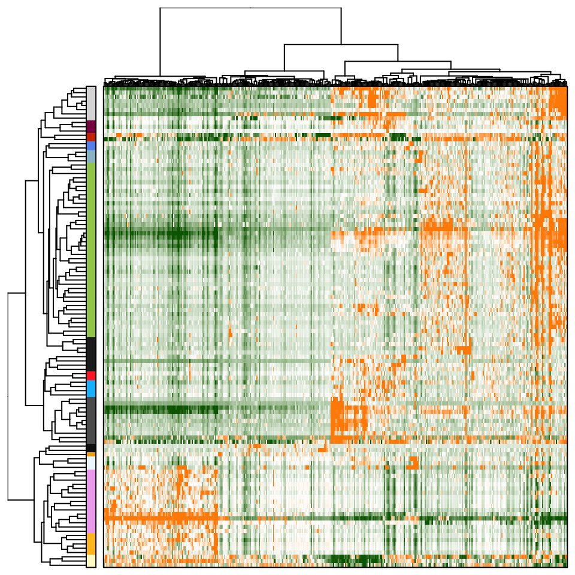

```r
all_days_DGE_scde_reduced_gene_clusters2 = pagoda.reduce.redundancy(all_days_DGE_scde_reduced_gene_clusters, distance.threshold = 0.9, plot = TRUE, cell.clustering = all_days_DGE_scde_cluster_cells, box = TRUE, margins = c(0.5,0.5))
```

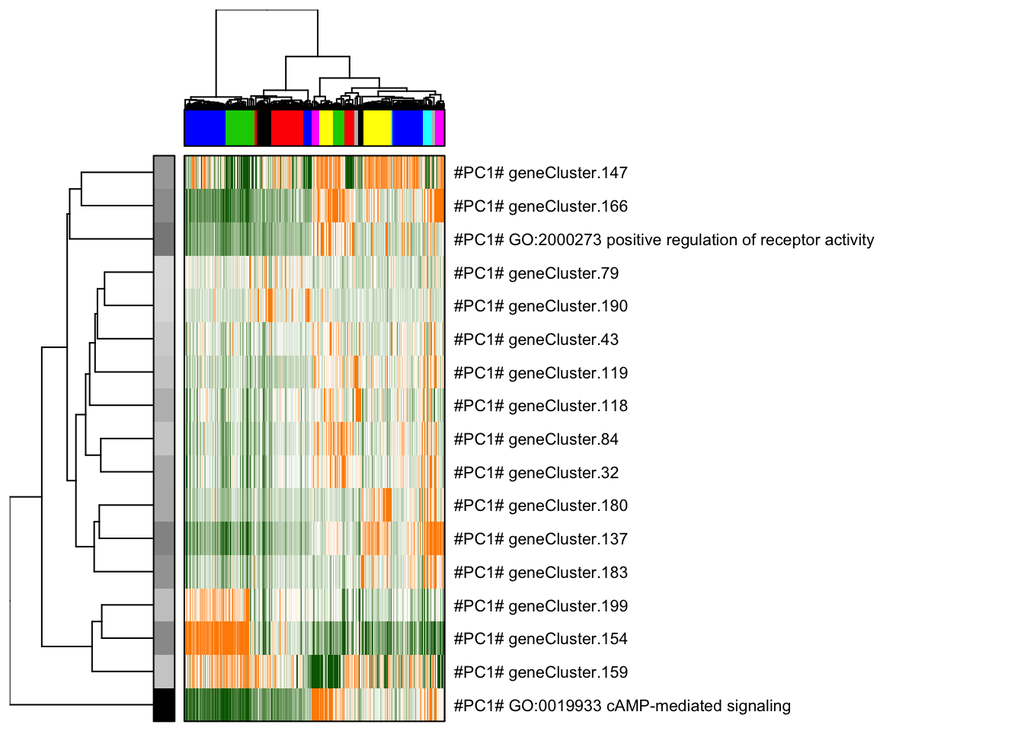

```r
col.cols <- rbind(groups = cutree(all_days_DGE_scde_cluster_cells, 20))
pagoda.view.aspects(all_days_DGE_scde_reduced_gene_clusters2, cell.clustering = all_days_DGE_scde_cluster_cells, box = TRUE, labCol = NA, margins = c(0.5, 30), col.cols = col.cols)
```